# ALS_Dream_Challenge: Clusters_Feature_Selector

### **II. Recursive Feature Selection with Random Forests**

```r
set.seed(134)
control <- rfeControl(functions=rfFuncs, method="cv", number=10)
#cluster 1 top features
cluster1_features <- rfe(training_set_cluster_1[,2:ncol(training_set_cluster_1)], training_set_cluster_1[,1], sizes=c(2:ncol(training_set_cluster_1)), rfeControl=control)
print(cluster1_features)
```

```
##
## Recursive feature selection
##
## Outer resampling method: Cross-Validated (10 fold)
##
## Resampling performance over subset size:
##
##  Variables   RMSE Rsquared    MAE RMSESD RsquaredSD   MAESD Selected
##          2 0.5171   0.6999 0.3217 0.2074    0.18880 0.09775
##          3 0.4466   0.7825 0.3111 0.1362    0.10113 0.06647
##          4 0.4708   0.7696 0.3293 0.1322    0.10336 0.07338
##          5 0.4713   0.7749 0.3417 0.1351    0.10835 0.07365
##          6 0.4515   0.7799 0.3002 0.1470    0.11572 0.07589
##          7 0.4309   0.8060 0.2906 0.1266    0.09403 0.07109
##          8 0.4315   0.8118 0.2925 0.1302    0.10151 0.06422
```

[output cut: 34 more lines]

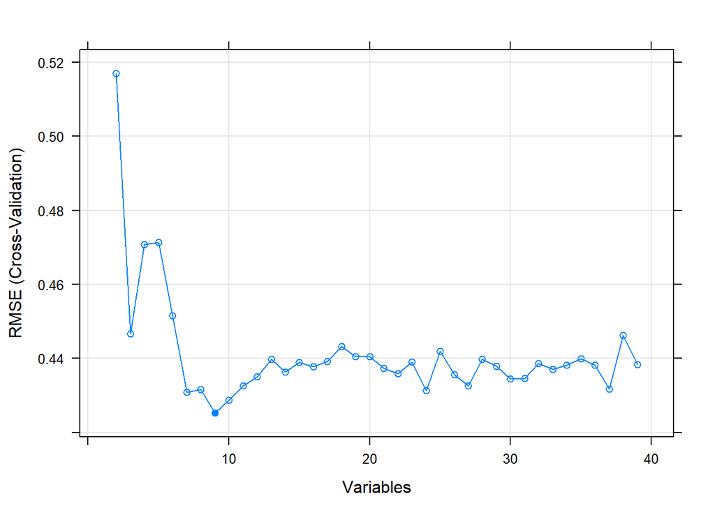

```r
plot(cluster1_features, type = c("g", "o"))
```

```r
# list the chosen features
predictors(cluster1_features, 6)
```

```
## [1] "Q3_Swallowing"            "Q2_Salivation"
## [3] "Site_of_Onset"            "Subject_Liters_Trial_1"
## [5] "Q7_Turning_in_Bed"        "Study_Arm"
## [7] "ALSFRS_Slope"             "Blood_Pressure_Diastolic"
## [9] "Respiratory_Rate"
```

```r
#cluster 2 top features
cluster2_features <- rfe(training_set_cluster_2[,2:ncol(training_set_cluster_2)], training_set_cluster_2[,1], sizes=c(2:ncol(training_set_cluster_2)), rfeControl=control)
print(cluster2_features)
```

```
##
## Recursive feature selection
##
## Outer resampling method: Cross-Validated (10 fold)
##
## Resampling performance over subset size:
##
##  Variables   RMSE Rsquared    MAE  RMSESD RsquaredSD    MAESD Selected
##          2 0.6116   0.6523 0.4653 0.02784    0.04628 0.017600
##          3 0.5425   0.7275 0.4037 0.01611    0.02982 0.011368
##          4 0.5251   0.7450 0.3910 0.01303    0.02283 0.008719
##          5 0.5108   0.7598 0.3771 0.01262    0.02153 0.010891
##          6 0.5107   0.7556 0.3624 0.01451    0.02519 0.011519
##          7 0.5045   0.7617 0.3591 0.01498    0.02473 0.011273
##          8 0.4945   0.7715 0.3530 0.01275    0.02396 0.007903
```

[output cut: 34 more lines]

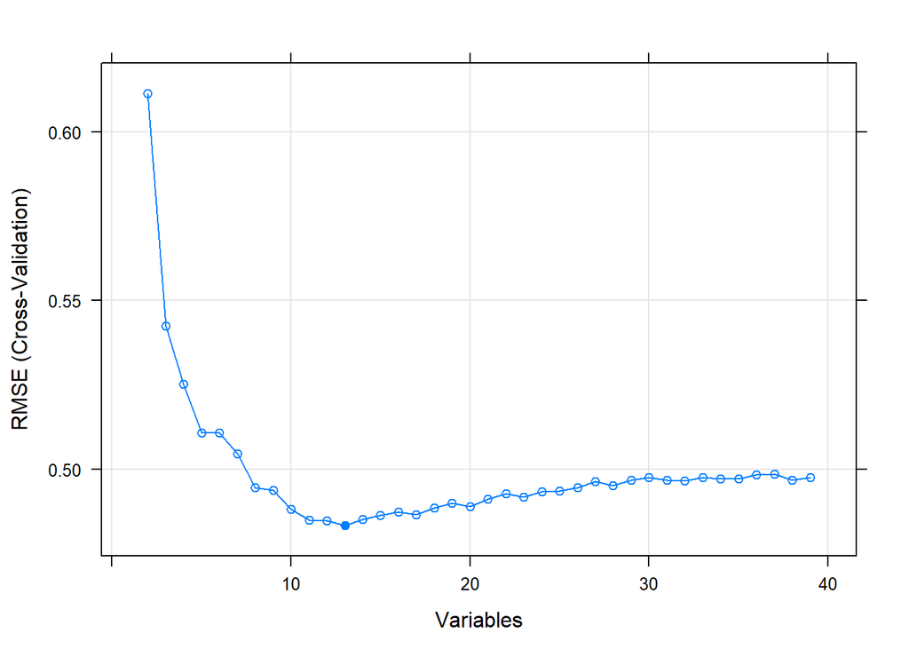

```r
plot(cluster2_features, type = c("g", "o"))
```

```r
# list the chosen features
predictors(cluster2_features, 6)
```

```
##  [1] "Site_of_Onset"                   "Q2_Salivation"
##  [3] "Q3_Swallowing"                   "Subject_Liters_Trial_1"
##  [5] "ALSFRS_Total"                    "Q5a_Cutting_without_Gastrostomy"
##  [7] "Q4_Handwriting"                  "Q9_Climbing_Stairs"
##  [9] "Q6_Dressing_and_Hygiene"         "Q7_Turning_in_Bed"
## [11] "Q8_Walking"                      "Q10_Respiratory"
## [13] "Age"
```

Based on recursive feature selection:

Cluster 1: Site_of_Onset, Q2_Salivation, Q3_Swallowing, Subject_Liters_Trial_1, Q7_Turning_in_Bed, and study_arm are the top 6 most important predictive variables.

Cluster 2: Q3_Swallowing, Q2_Salivation, Site_of_Onset, Subject_Liters_Trial_1, ALSFRS_Total, Q5a_Cutting_without_Gastrostomy are the top 6 most important predictive variables.

### **III. Select the 6 Features and Create CSV files for each of the clusters**

Now that we have determined the top features for prediction for each cluster, two separate csv files will be created, which will be used for the prediction algorithms.

```r
training_set_cluster_1_file <- training_set_clusters %>% filter(Cluster_Number==1) %>% select(subject_id, ALSFRS_Slope, Q3_Swallowing, Q2_Salivation, Site_of_Onset, Subject_Liters_Trial_1, Q7_Turning_in_Bed, Study_Arm  )
write.csv(training_set_cluster_1_file, file = "cluster_1.csv")

#cluster 2
training_set_cluster_2_file <- training_set_clusters %>% filter(Cluster_Number==2) %>% select(subject_id, ALSFRS_Slope, Site_of_Onset, Q2_Salivation, Q3_Swallowing, Subject_Liters_Trial_1, ALSFRS_Total, Q5a_Cutting_without_Gastrostomy )
write.csv(training_set_cluster_2_file, file = "cluster_2.csv")
```